# Part I - Prosper Loan Data Exploration

## By: Morris Muchiri Mugo

## Introduction

#### Some of the questions to Investigate.

1. What factors affect a loans outcome status?
2. What affects the borrower APR or Interest Rate?
3. Are there differences between Loans depending on how large the original loan amount was?
4. Which Listing category had the highest and which had the lowest number of people taking Loans?
5. How has the Borrower Rate been over the years?
6. How has the numbers of Investors been over the years? ## Preliminary Wrangling

```python
# import all packages and set plots to be embedded inline
import numpy as np
import pandas as pd
import matplotlib.pyplot as plt
import seaborn as sb

%matplotlib inline
# suppress warnings from final output
import warnings
warnings.simplefilter("ignore")
```

> Load in your dataset and describe its properties through the questions below. Try and motivate your exploration goals through this section.

```python
df = pd.read_csv('prosperLoanData.csv')
df.head()
```

|  | ListingKey | ListingNumber | ListingCreationDate | CreditGrade | Term | LoanStatus | ClosedDate | BorrowerAPR | BorrowerRate | LenderYield | ... | LP_ServiceFees | LP_CollectionFees | LP_GrossPrincipalLoss | LP_NetPrincipalLoss | LP_NonPrincipalRecoverypayments | PercentFunded | Recommendations | InvestmentFromFriendsCount | InvestmentFromFriendsAmount | Investors |
| --- | --- | --- | --- | --- | --- | --- | --- | --- | --- | --- | --- | --- | --- | --- | --- | --- | --- | --- | --- | --- | --- |
| 0 | 1021339766868145413AB3B | 193129 | 2007-08-26 19:09:29.263000000 | C | 36 | Completed | 2009-08-14 00:00:00 | 0.16516 | 0.1580 | 0.1380 | ... | -133.18 | 0.0 | 0.0 | 0.0 | 0.0 | 1.0 | 0 | 0 | 0.0 | 258 |
| 1 | 10273602499503308B223C1 | 1209647 | 2014-02-27 08:28:07.900000000 | NaN | 36 | Current | NaN | 0.12016 | 0.0920 | 0.0820 | ... | 0.00 | 0.0 | 0.0 | 0.0 | 0.0 | 1.0 | 0 | 0 | 0.0 | 1 |
| 2 | 0EE9337825851032864889A | 81716 | 2007-01-05 15:00:47.090000000 | HR | 36 | Completed | 2009-12-17 00:00:00 | 0.28269 | 0.2750 | 0.2400 | ... | -24.20 | 0.0 | 0.0 | 0.0 | 0.0 | 1.0 | 0 | 0 | 0.0 | 41 |
| 3 | 0EF5356002482715299901A | 658116 | 2012-10-22 11:02:35.010000000 | NaN | 36 | Current | NaN | 0.12528 | 0.0974 | 0.0874 | ... | -108.01 | 0.0 | 0.0 | 0.0 | 0.0 | 1.0 | 0 | 0 | 0.0 | 158 |
| 4 | 0F023589499656230C5E3E2 | 909464 | 2013-09-14 18:38:39.097000000 | NaN | 36 | Current | NaN | 0.24614 | 0.2085 | 0.1985 | ... | -60.27 | 0.0 | 0.0 | 0.0 | 0.0 | 1.0 | 0 | 0 | 0.0 | 20 |

5 rows × 81 columns

## Assess the Data

```python
df.info()
```

```
<class 'pandas.core.frame.DataFrame'>
RangeIndex: 113937 entries, 0 to 113936
Data columns (total 81 columns):
 #   Column                               Non-Null Count   Dtype
---  ------                               --------------   -----
 0   ListingKey                           113937 non-null  object
 1   ListingNumber                        113937 non-null  int64
 2   ListingCreationDate                  113937 non-null  object
 3   CreditGrade                          28953 non-null   object
 4   Term                                 113937 non-null  int64
 5   LoanStatus                           113937 non-null  object
 6   ClosedDate                           55089 non-null   object
 7   BorrowerAPR                          113912 non-null  float64
 8   BorrowerRate                         113937 non-null  float64
 9   LenderYield                          113937 non-null  float64
```

[output cut: 73 more lines]

```python
df.duplicated().sum()
```

```
0
```

### Quality Issues

1. There are many rows where `Proper score & Proper Rating` are nulls
2. The following variables are in using datatypes that won't be suitable for developing visuals `Proper score, Open Revolving monthly payments, Total inquiries, Revolving credit Balance, Available Bank card credit, Total trades, Stated monthly income`
3. The following variables are in using datatypes that won't be suitable for developing visuals `list category, Employment status, Is Borrower Home owner, Currently in a group`

## Cleaning

Issue#1: There are many rows where `Proper score & Proper Rating` are nulls

```python
df1 = df.copy()
```

#### Define

> Drop all the null values in one column i.e `Proper Score`

#### Code

```python
df1.ProsperScore.isnull().sum()
```

```
29084
```

```python
df1.dropna(subset = "ProsperScore", inplace=True)
```

#### Test

```python
df1.ProsperScore.isnull().sum()
```

```
0
```

```python
df1.shape
```

```
(84853, 81)
```

Isue#2: The following variables are in using datatypes that won't be suitable for developing visuals `Proper score, Open Revolving monthly payments, Total inquiries, Revolving credit Balance, Available Bank card credit, Total trades, Stated monthly income`

```python
df1 = df1.astype({'ProsperScore': 'int64', 'OpenRevolvingMonthlyPayment': 'int64', 'TotalInquiries': 'int64',
                  'RevolvingCreditBalance': 'int64', 'AvailableBankcardCredit': 'int64', 'TotalTrades': 'int64',
                  'StatedMonthlyIncome': 'int64'})
```

Issue#3: The following variables are in using datatypes that won't be suitable for developing visuals `list category, Employment status, Is Borrower Home owner, Currently in a group`

```python
df1 = df1.astype({'ListingCategory (numeric)': 'category', 'EmploymentStatus': 'category', 'IsBorrowerHomeowner': 'category',
                  'CurrentlyInGroup': 'category'})
```

```python
df1['ProsperRating (Alpha)'] = df1['ProsperRating (Alpha)'].astype('category')
```

```python
df1.info()
```

```
<class 'pandas.core.frame.DataFrame'>
Int64Index: 84853 entries, 1 to 113936
Data columns (total 81 columns):
 #   Column                               Non-Null Count  Dtype
---  ------                               --------------  -----
 0   ListingKey                           84853 non-null  object
 1   ListingNumber                        84853 non-null  int64
 2   ListingCreationDate                  84853 non-null  object
 3   CreditGrade                          0 non-null      object
 4   Term                                 84853 non-null  int64
 5   LoanStatus                           84853 non-null  object
 6   ClosedDate                           26005 non-null  object
 7   BorrowerAPR                          84853 non-null  float64
 8   BorrowerRate                         84853 non-null  float64
 9   LenderYield                          84853 non-null  float64
```

[output cut: 73 more lines]

### What is the structure of your dataset?

> There are 84,853 entries after a short clean up and 81 columns

### What is/are the main feature(s) of interest in your dataset?

- Borrower APR
- Borrower Rate
- Prosper Rating (Alpha)
- List Category
- Employement Status
- Stated monthly income
- Loan Original amount
- Monthly Loan Payment ### What features in the dataset do you think will help support your investigation into your feature(s) of interest?
- Loan Status
- Debt to income Ratio
- Prosper score
- Employment status duration
- Is Borrower Home Owner
- Currently in a group
- Total Credit Line past 7 years
- Open Revolving monthly payment
- Total inquiries
- Current Delinguencies
- Revolving credit balance
- Available Bankcard credit
- Total trades
- Investors

## Univariate Exploration

> In this section, investigate distributions of individual variables. If you see unusual points or outliers, take a deeper look to clean things up and prepare yourself to look at relationships between variables.

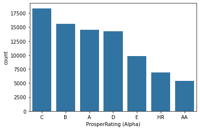

```python
# Plotting the distribution of Prosper Rating
base_color = sb.color_palette()[0]

def plot_bar (a):
    base_color = sb.color_palette()[0]
    prating_counts = df1[a].value_counts()
    prating_order = prating_counts.index
    sb.countplot(data=df1, x=a, color=base_color, order=prating_order)
    return plot_bar

plot_bar('ProsperRating (Alpha)');
```

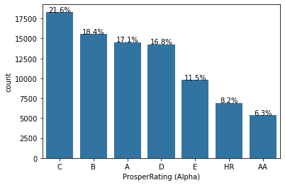

```python
# Plotting the distribution of Prosper Rating

p_list = df1['ProsperRating (Alpha)'].value_counts().sum()

plot_bar('ProsperRating (Alpha)');

# Recalculating the type_counts just to have clarity.
pr_counts = df1['ProsperRating (Alpha)'].value_counts()

# get the current tick locations and labels
locs, labels = plt.xticks(rotation=0)

# loop through each pair of locations and labels
for loc, label in zip(locs, labels):

    # get the text property for the label to get the correct count
    count = pr_counts[label.get_text()]
    pct_string = '{:0.1f}%'.format(100*count/p_list)

    # print the annotation just below the top of the bar
    plt.text(loc, count+2, pct_string, ha = 'center', color = 'black')
```

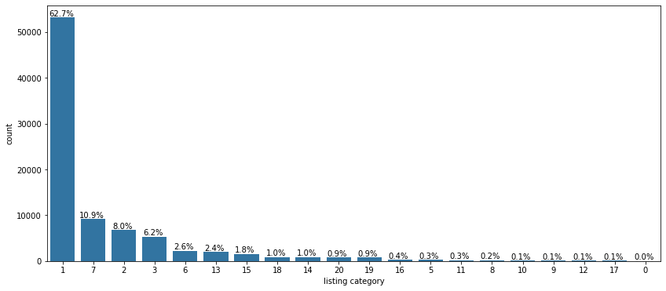

```python
# Plotting the distribution of Listing Category

listing_counts = df1['ListingCategory (numeric)'].value_counts()
listing_order = listing_counts.index

plt.figure(figsize = [14, 6])
ax = sb.countplot(x="ListingCategory (numeric)", data=df1, color=base_color, order=listing_order)

# This function is used to change the count plot numbers into percentages
def without_hue(plot, feature):
    total = len(feature)
    for p in plot.patches:
        percentage = '{:.1f}%'.format(100 * p.get_height()/total)
        x = p.get_x() + p.get_width() / 2 - 0.05
        y = p.get_y() + p.get_height()
        plot.annotate(percentage, (x, y), size = 10, va='bottom', ha='center')

without_hue(ax, df1['ListingCategory (numeric)'])
plt.xlabel('listing category');
```

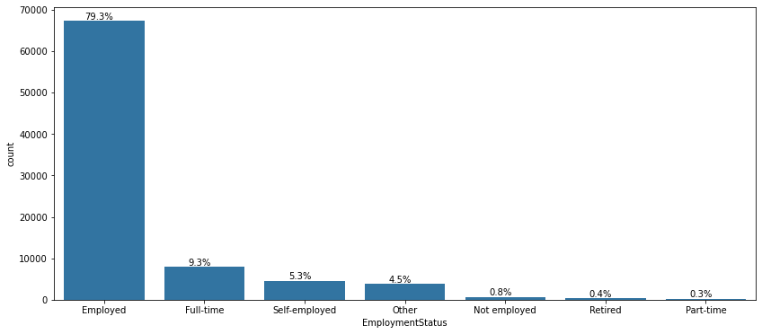

```python
# Plotting the distribution of Employment status

employ_counts = df1['EmploymentStatus'].value_counts()
employ_order = employ_counts.index

plt.figure(figsize = [14, 6])
ax = sb.countplot(data=df1, x="EmploymentStatus", color=base_color, order=employ_order)

without_hue(ax, df1['EmploymentStatus'])
plt.xticks(rotation=0);
```

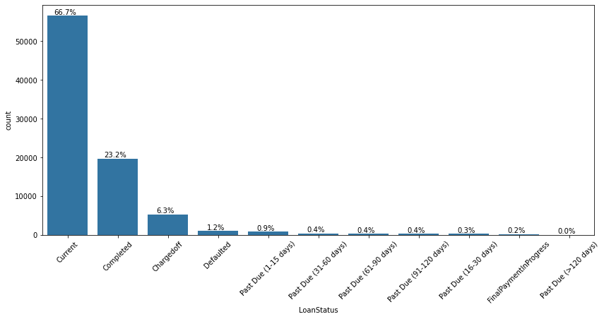

```python
# Plotting the distribution of Loan Status
loan_counts = df1['LoanStatus'].value_counts()
loan_order = loan_counts.index

plt.figure(figsize = [14, 6])
ax = sb.countplot(data=df1, x="LoanStatus", color=base_color, order=loan_order)

without_hue(ax, df1['LoanStatus'])
plt.xticks(rotation=45);
```

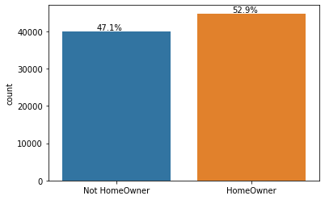

```python
# Plotting the distribution of Home Ownership
ticks = df1.IsBorrowerHomeowner.value_counts().index
labels = ['HomeOwner','Not HomeOwner']

ax = sb.countplot(data=df1, x="IsBorrowerHomeowner")
without_hue(ax, df1['IsBorrowerHomeowner'])
plt.xticks(ticks,labels)
plt.xlabel('');
```

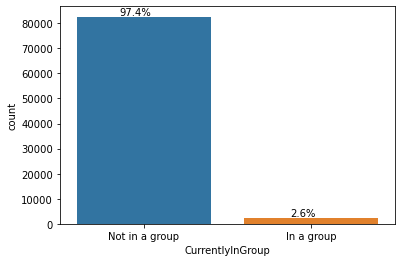

```python
# Plotting the distribution of whether they are in a group or not
ticks = df1.CurrentlyInGroup.value_counts().index
labels = ['Not in a group','In a group']

ax = sb.countplot(data=df1, x="CurrentlyInGroup")
without_hue(ax, df1['CurrentlyInGroup'])
plt.xticks(ticks,labels);
```

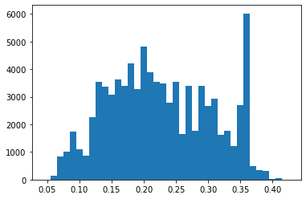

```python
# Plotting the distribution of BorrowerARP
bins = np.arange(0.045, df1['BorrowerAPR'].max()+0.01, 0.01)

def histogram (a,b):
    plt.hist(df1[a], bins = b)
    return histogram
histogram('BorrowerAPR',bins);
```

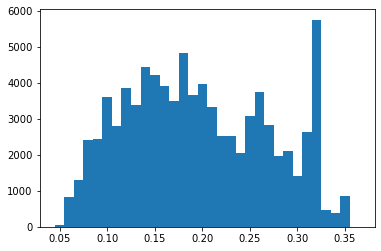

```python
# Plotting the distribution of Borrower Rate
bins = np.arange(0.045, df1['BorrowerRate'].max()+0.01, 0.01)
histogram('BorrowerRate',bins);
```

```python
np.log10(df1['BorrowerRate'].describe())
```

```
count    4.928667
mean    -0.707696
std     -1.127080
min     -1.397940
25%     -0.866781
50%     -0.726999
75%     -0.589391
max     -0.443697
Name: BorrowerRate, dtype: float64
```

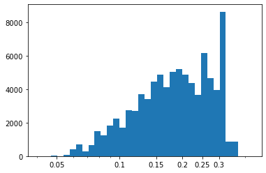

```python
bins = 10 ** np.arange(-1.39, -0.44+0.1, 0.03)
ticks = [0.05, 0.10, 0.15, 0.20, 0.25, 0.30]
# Convert ticks into string values, to be displaye dlong the x-axis
labels = ['{}'.format(v) for v in ticks]

histogram('BorrowerRate',bins)
plt.xscale('log')
plt.xticks(ticks, labels);
```

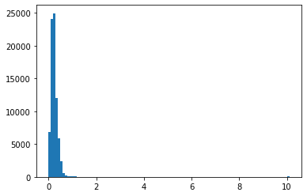

```python
# Plotting the distribution of Debt to Income Ratio
bins = np.arange(0, df1['DebtToIncomeRatio'].max()+0.1, 0.1)
histogram('DebtToIncomeRatio',bins);
```

```python
 df1['DebtToIncomeRatio'].describe()
```

```
count    77557.000000
mean         0.258752
std          0.318326
min          0.000000
25%          0.150000
50%          0.220000
75%          0.320000
max         10.010000
Name: DebtToIncomeRatio, dtype: float64
```

### Another Quality Issue

> There are outliers

```python
q = df1["DebtToIncomeRatio"].quantile(0.99)
df1 = df1[df1["DebtToIncomeRatio"] < q]
```

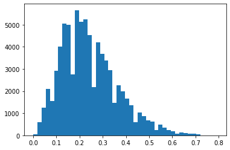

```python
bins = np.arange(0, df1['DebtToIncomeRatio'].max()+0.1, 0.018)
histogram('DebtToIncomeRatio',bins);
```

```python
q = df1["StatedMonthlyIncome"].quantile(0.99)
df1 = df1[df1["StatedMonthlyIncome"] < q]
```

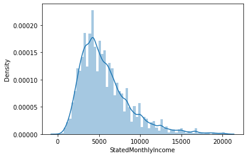

```python
# Plotting the distribution of Stated Monthly Income
bins = np.arange(150, df1['StatedMonthlyIncome'].max()+1000, 300)
sb.distplot(df1['StatedMonthlyIncome'], bins = bins);
```

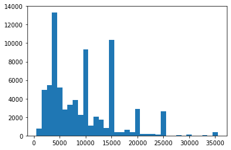

```python
# Plotting the distribution of Loan Original Amount
bins = np.arange(500, df1['LoanOriginalAmount'].max()+1000, 1000)
histogram('LoanOriginalAmount',bins);
```

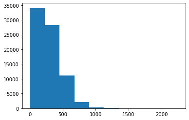

```python
# Plotting the distribution of Monthly Loan payments
plt.hist(df1['MonthlyLoanPayment']);
```

```python
# Lets remove the outliers at 99 %
q = df1["MonthlyLoanPayment"].quantile(0.99)
df1 = df1[df1["MonthlyLoanPayment"] < q]
```

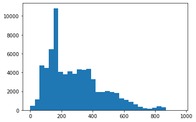

```python
bins = np.arange(0, df1['MonthlyLoanPayment'].max()+100, 30)
histogram('MonthlyLoanPayment',bins);
```

```python
df1['Loan_Start_Date'] = df1['LoanOriginationQuarter'].str.extract('(\d{4})', expand=True)
```

```python
cols = ['BorrowerAPR','BorrowerRate','ProsperRating (Alpha)','ListingCategory (numeric)','EmploymentStatus','DebtToIncomeRatio','StatedMonthlyIncome','LoanOriginalAmount',
        'MonthlyLoanPayment','LoanStatus','EmploymentStatusDuration','IsBorrowerHomeowner','CurrentlyInGroup','TotalCreditLinespast7years','OpenRevolvingMonthlyPayment',
        'TotalInquiries','CurrentDelinquencies','RevolvingCreditBalance','AvailableBankcardCredit','TotalTrades','Loan_Start_Date', 'Investors']
df1 = df1[cols]
```

```python
df1.to_csv('Cleaned_ProsperLoanData.csv', index=False)
```

### Of the features you investigated, were there any unusual distributions? Did you perform any operations on the data to tidy, adjust, or change the form of the data? If so, why did you do this?

- In the `Debt to Income Ratio`, `Stated Monthly Income` and `Monthly Loan Payment` there were Outliers which I observed when I ploted their Histograms and removed them at the **99 percentile**

## Bivariate Exploration

> In this section, investigate relationships between pairs of variables in your data. Make sure the variables that you cover here have been introduced in some fashion in the previous section (univariate exploration).

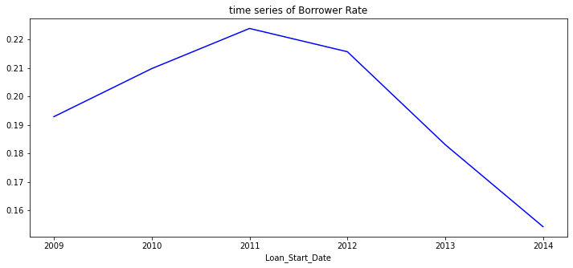

```python
# Plotting a timeseries of BorrowerRate
def timeseries (a,b,c,d,e):
    df1.groupby(a)[b].mean().plot(kind = c, figsize = (12,5), c = d, title = e)
    return timeseries

timeseries ('Loan_Start_Date','BorrowerRate','line','blue','time series of Borrower Rate');
```

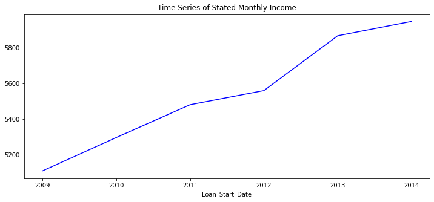

```python
# Plotting a timeseries of Stated Monthly Income
timeseries ('Loan_Start_Date','StatedMonthlyIncome','line','blue','Time Series of Stated Monthly Income');
```

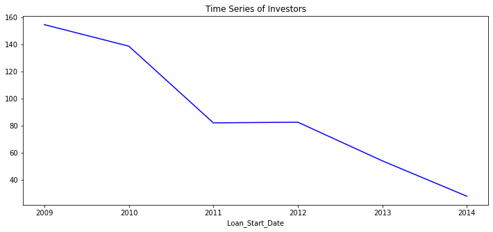

```python
# Plotting a timeseries of Investors
timeseries ('Loan_Start_Date','Investors','line','blue','Time Series of Investors');
```

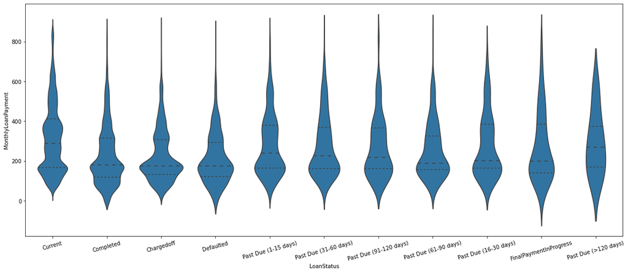

```python
# check the relationship between loan outcome status and the monthly loan payment
def violin_plot (a,b):
    plt.figure(figsize = [20,8])
    loan_counts = df1[a].value_counts()
    loan_order = loan_counts.index

    sb.violinplot(data=df1, x=a, y=b, color=base_color, inner='quartile',order=loan_order)
    plt.xticks(rotation=15)
    return violin_plot

violin_plot('LoanStatus','MonthlyLoanPayment');
```

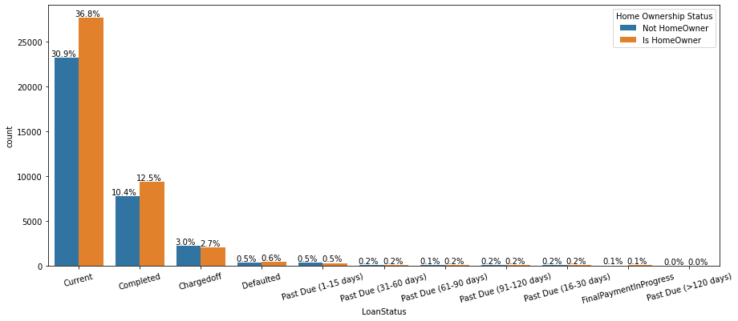

```python
# check the relationship between loan outcome status and Home Owner
plt.figure(figsize = [15, 6])
legend_labels = ['Not HomeOwner', 'Is HomeOwner']

ax = sb.countplot(data = df1, x = 'LoanStatus', hue = 'IsBorrowerHomeowner', order=loan_order)
without_hue(ax, df1['LoanStatus'])
# loc = 'upper left'
plt.legend(labels = legend_labels, title = 'Home Ownership Status')
plt.xticks(rotation=15);
```

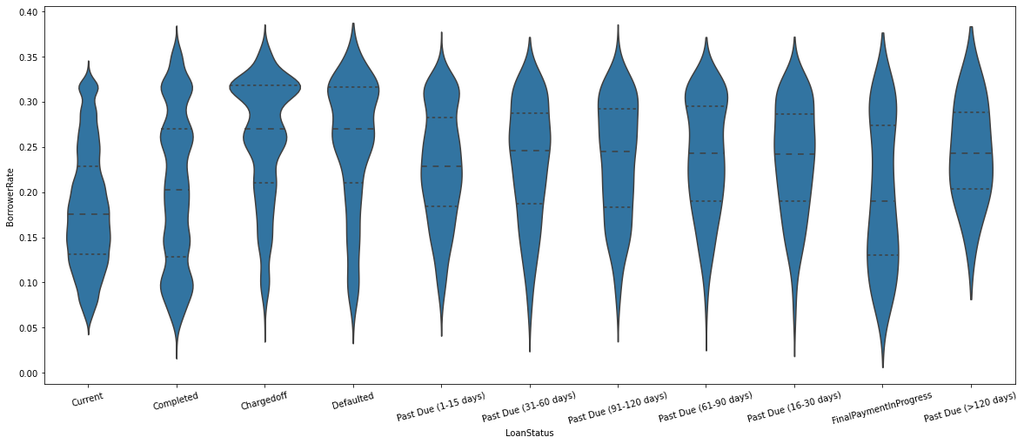

```python
# check the relationship between loan outcome status and Borrower Rate
violin_plot('LoanStatus','BorrowerRate');
```

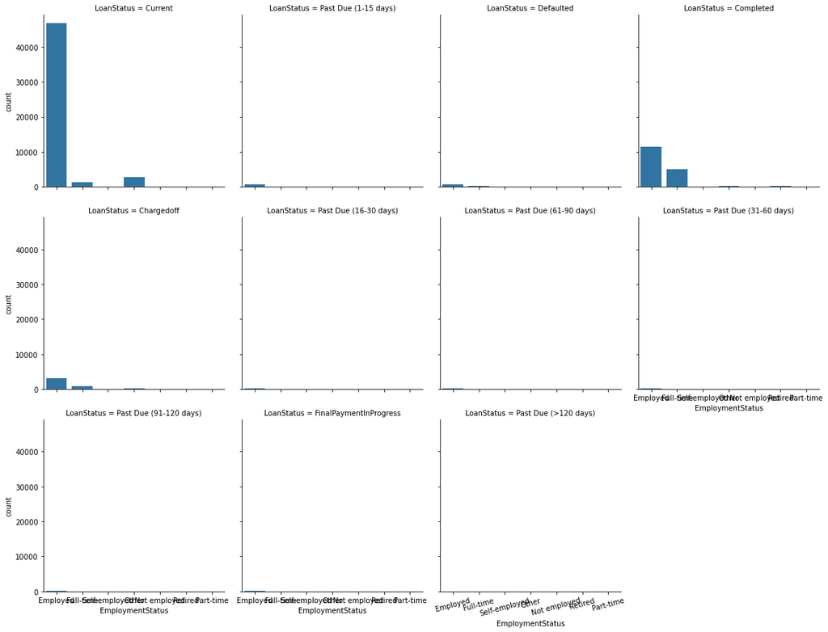

```python
# check the relationship between loan outcome status and Employment status

plt.figure(figsize = [15, 6])
g = sb.FacetGrid(data = df1, col = 'LoanStatus', col_wrap = 4, height = 4)
g.map(sb.countplot, 'EmploymentStatus', order=employ_order)
plt.xticks(rotation=15);
```

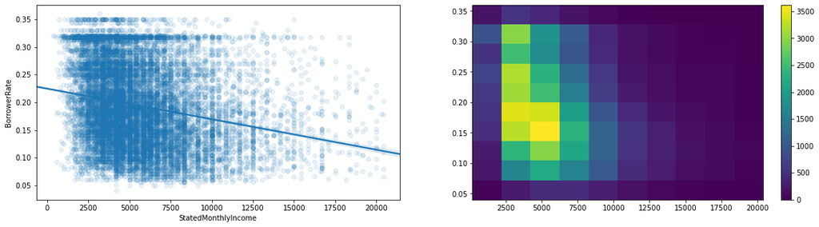

```python
# check the relationship between Borrower rate and StatedMonthlyIncome
plt.figure(figsize = [20, 5])
sample1 = df1.sample(n = 15000)
sample1.shape

plt.subplot(1, 2, 1)
sb.regplot(data = sample1, x = 'StatedMonthlyIncome', y = 'BorrowerRate', truncate=False, x_jitter=0.3,scatter_kws={'alpha':1/10});

plt.subplot(1, 2, 2)
plt.hist2d(data = df1, x = 'StatedMonthlyIncome', y = 'BorrowerRate')
plt.colorbar();
```

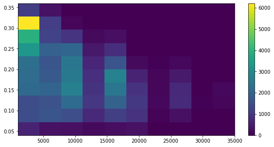

```python
# check the relationship between Borrower rate and LoanOriginalAmount

def histo(x,y):
    plt.figure(figsize = [10, 5])
    plt.hist2d(data = df1, x = x, y = y)
    plt.colorbar();

histo('LoanOriginalAmount','BorrowerRate')
```

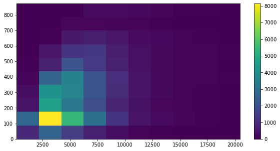

```python
# check the relationship between Stated Monthly Income and MonthlyLoanPayment
histo('StatedMonthlyIncome','MonthlyLoanPayment')
```

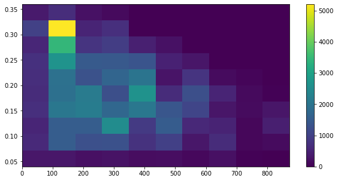

```python
# check the relationship between Borrower rate and MonthlyLoanPayment
histo('MonthlyLoanPayment','BorrowerRate')
```

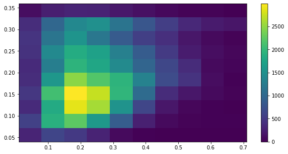

```python
# check the relationship between Borrower rate and DebtToIncomeRatio
histo('DebtToIncomeRatio','BorrowerRate')
```

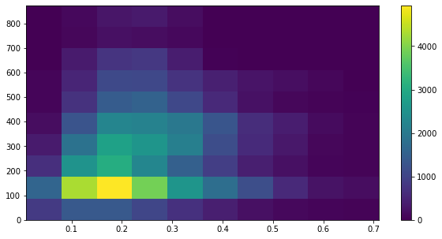

```python
# check the relationship between DebtToIncomeRatio and MonthlyLoanPayment
histo('DebtToIncomeRatio','MonthlyLoanPayment')
```

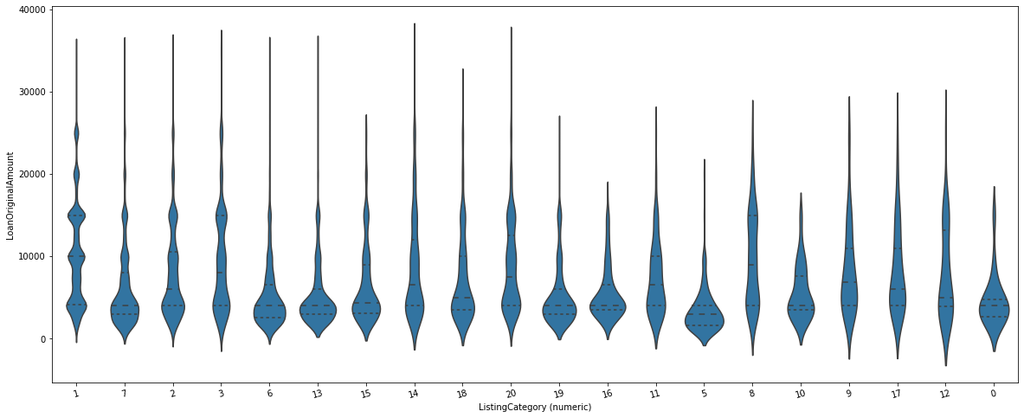

```python
# check the relationship between Listing Category and LoanOriginalAmount
violin_plot('ListingCategory (numeric)','LoanOriginalAmount');
```

### Talk about some of the relationships you observed in this part of the investigation. How did the feature(s) of interest vary with other features in the dataset?

- There was a positive correlation between `Debt to income Ratio` and the features of Interest like `Borrower Rate` and `Monthly Loan Payment`
- There was a negative correlation between `Borrower Rate` and the features of Interest like `Loan Original Amount` and `Monthly Loan Payment` ### Did you observe any interesting relationships between the other features (not the main feature(s) of interest)?
- From the **Timeseries** of `Borrower Rate` using `Loan Start Date` I observed that the `Borrower Rate` has been increasing from 2009 till 2011 when it started falling and 2014 was at it lowest.
- From the **Timeseries** of `Stated Monthly Income` using `Loan Start Date` I observed that the `Stated Monthly Income` has been increasing through the years.
- From the **Timeseries** of `Investors` using `Loan Start Date` I observed that the number of `Investors` has been declining through the years.
- From the **Violin plot** of the `LoanStatus` against the `MonthlyLoanPayments` I observed that those who their status was `Current` had the highest Monthly Payemnts.

## Multivariate Exploration

> Create plots of three or more variables to investigate your data even further. Make sure that your investigations are justified, and follow from your work in the previous sections.

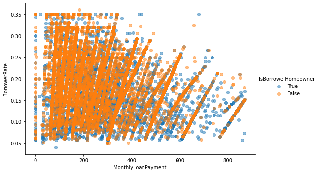

```python
# check that the dependent variable should be in the Y-axis
# check the relationship between Borrower rate and MonthlyLoanPayment and Home Owner

g = sb.FacetGrid(data = sample1, hue = 'IsBorrowerHomeowner',hue_order=[True, False] , height=5, aspect = 1.5)
g.map(plt.scatter, 'MonthlyLoanPayment', 'BorrowerRate',alpha = 1/2)
g.add_legend();

#plt.figure(figsize=(12,4), dpi = 200)
#sb.scatterplot(data = df1, x = 'MonthlyLoanPayment', y = 'BorrowerRate',  hue = 'IsBorrowerHomeowner', hue_order=[True,False], style = 'IsBorrowerHomeowner' );
```

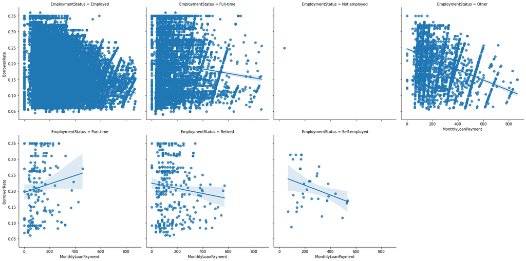

```python
# check the relationship between Borrower rate and MonthlyLoanPayment and Employment status
def multi_plots(a,b,c):
    g = sb.FacetGrid(data = df1, col = a, col_wrap = 4, height = 5)
    g.map(sb.regplot, b, c)
    return multi_plots

multi_plots('EmploymentStatus','MonthlyLoanPayment','BorrowerRate');
```

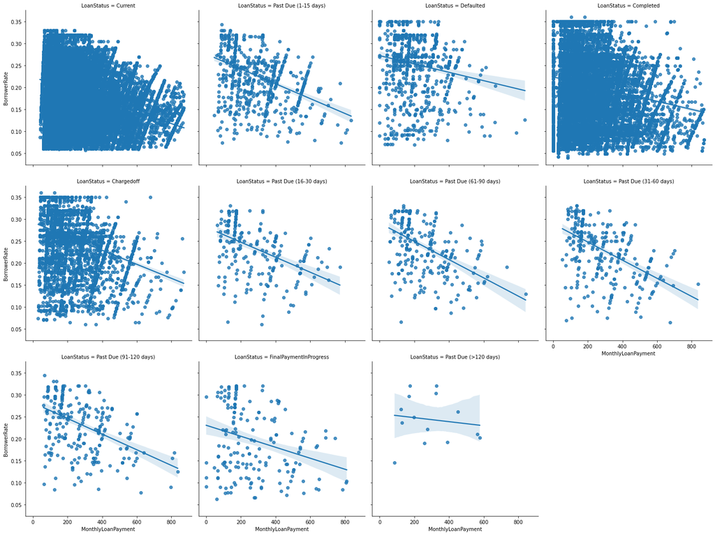

```python
# check the relationship between Borrower rate and MonthlyLoanPayment and loan status
multi_plots('LoanStatus','MonthlyLoanPayment','BorrowerRate');
```

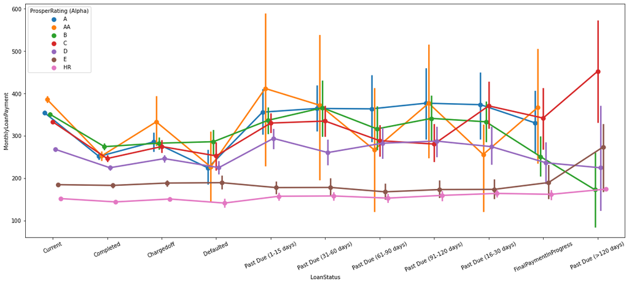

```python
# check the relationship between loan outcome status and the monthly loan payment and ProsperRating (Alpha)
def multi_line(a,b,c):
    plt.figure(figsize = [20, 8])
    ax = sb.pointplot(data = df1, x = a, y = b, hue = c, order=loan_order, dodge = 0.3)
    plt.xticks(rotation=25)
    return multi_line

multi_line('LoanStatus','MonthlyLoanPayment','ProsperRating (Alpha)');
```

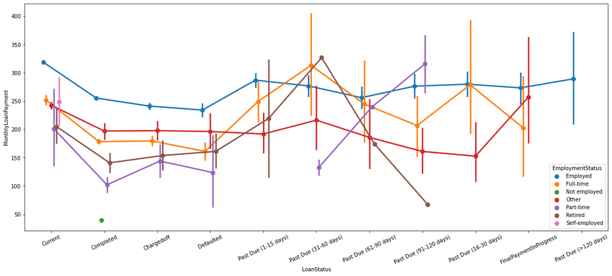

```python
# check the relationship between loan outcome status and the monthly loan payment and Employment status
multi_line('LoanStatus','MonthlyLoanPayment','EmploymentStatus');
```

```python
df1.BorrowerRate.describe()
```

```
count    75233.000000
mean         0.193388
std          0.073741
min          0.040000
25%          0.134900
50%          0.184500
75%          0.251100
max          0.360000
Name: BorrowerRate, dtype: float64
```

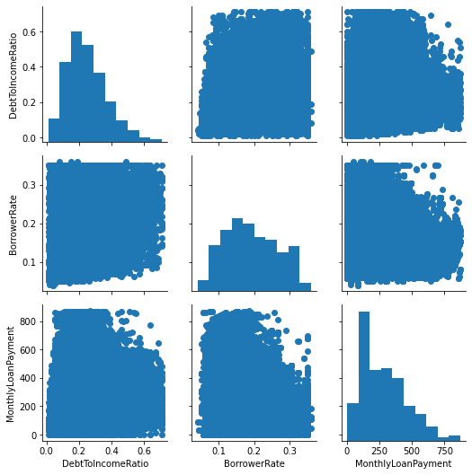

```python
# Create 3 qualitative variables
# check the relationship between Borrower rate and DebtToIncomeRatio and Monthly Loan Payment

g = sb.PairGrid(data = df1, vars = ['DebtToIncomeRatio', 'BorrowerRate', 'MonthlyLoanPayment'])
g.map_diag(plt.hist)
g.map_offdiag(plt.scatter);
```

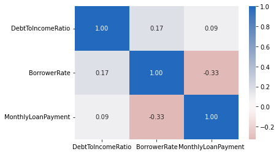

```python
col_1 = ['DebtToIncomeRatio', 'BorrowerRate', 'MonthlyLoanPayment']
sb.heatmap(df1[col_1].corr(), annot = True, fmt = '.2f', cmap = 'vlag_r', center = 0);
```

### Were there any interesting or surprising interactions between features?

- None

## Conclusions: *A summary of the main findings and reflect on the steps taken during the data exploration*

- Some of the factors that affect a Loan outcome Status are `Borrower Rate`, `Monthly Loan Payment` and `Prosper Rating`
- The `Original Loan Amount`, `Monthly Loan Payment` and `Debt to Income Ratio` affect the Borrower Rate.
- Yes there are differences between Loans depending on how large the Original Loan Amount was.
- The monthly Income of those who get the Loans tends to increase through the years.
- The Number of loan Investors tend to decrease through the years.